# R Open Labs, Week 4: User-Defined Functions

Chelsea Estancona

One of the most flexible things about R is our ability to write our own functions. A function, in R, is basically an operation (or series of operations) that we can save and apply to an object we bring in from elsewhere or create.

```r
library(ggplot2)
fun_x <- function(x){ #open brackets
  corgis <- -(x-6)^2 + 4 #names within functions are meaningless
  return(corgis) #what is our expected output?
}

fun_x(5)
```

```
## [1] 3
```

We can use functions for math, as above, or for practical applications on data. What does the function below do?

```r
my.mean <- function(x){
  n <- length(x)
  themean <- sum(x)/n
  return(themean)
}

set.seed(23785)
my.vec<-rnorm(100)

my.mean(my.vec)
```

```
## [1] 0.01199464
```

This function is a little redundant when we could just use mean(). But it’s a helpful illustration of what R is doing when we’re applying built-in functions. Let’s get a little more complicated.

First, a note about scoping. In R (and other computing languages), the objects and variables we define can have differing scope. ‘Global scope’ indicates things that show up in our global environment - we’ve defined them in our basic R script. ‘Local scope’ refers to things we’ve defined in a function or other block of code. In the example below, do x and y have global or local scope, respectively? What’s the output of this function?

```r
x <- 2
g <- function() {
  y <- 1
  c(x, y)
}
#g()
```

This can get even a bit more complicated: we can create functions within functions (like ogres and onions, they can have layers).

```r
j <- function(z) {
  d <- 2
  function() {
    z+d
  }
}
k <- j(4)
k()
```

```
## [1] 6
```

In this instance, the function saved within j doesn’t exist outside- but R will remember the value 2 for d when computing k (which is also a function!). Overall, it’s helpful to make sure the objects you create within a function differ from the names of objects you create in your global environment!

Let’s try a more applicable example: we’ll write a simple function to calculate the variance of a single random variable, and check it against R’s built-in function. To do so, we’ll use R’s built-in data about car models: mtcars, specifically the miles per gallon variable.

```r
data(mtcars)
variance <- function(x) {
    n <- length(x)
    m <- mean(x)
    (1/(n)) * sum((x - m)^2)
}

variance(mtcars$mpg)
```

```
## [1] 35.18897
```

```r
var(mtcars$mpg)
```

```
## [1] 36.3241
```

Why do these differ?! It’s slight, but it’s because R’s built in function uses the following variance equation:
$$\sigma^2 = \frac{\sum(x-\mu^2)}{(n-1)}$$
whereas some definitions use
$$\sigma^2 = \frac{\sum(x-\mu^2)}{(n)}$$
It’s an important distinction to be aware of – but now you have the tools to write your own function if you prefer!

One more applicable example: We can write a function that computes a standard regression diagnostic and plots the results all in one. Useful if we want flexibility with different models and different observations!

Below, we’ll find and plot Cook’s Distance, a measure of observations’ influence.

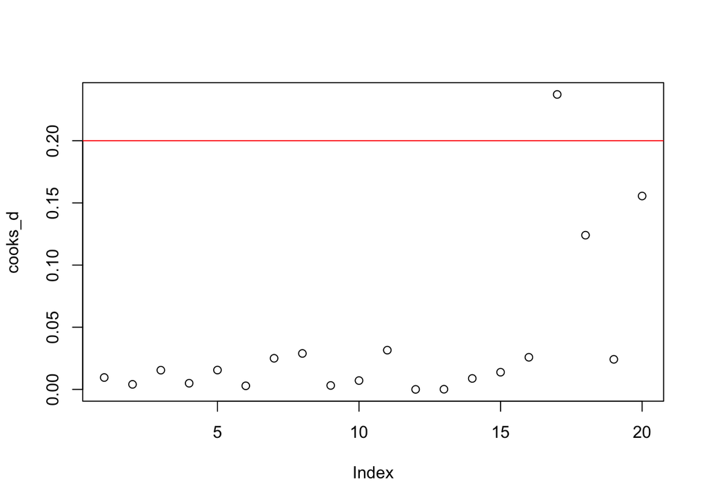

```
## integer(0)
```

```r
data(mtcars) #Make sure your data is loaded
m1<-lm(mpg~disp+wt, data=mtcars) #simple regression model

#Now, the function
cooks<-function(LM, x){ #2 arguments
  resid<-LM$residuals[x] #x allows for flexibility in the number of observations
  k<-length(LM$coefficients) #number of coefficients estimated
  num_1<-resid^2 #squared residuals
  denom_1<-mean(resid^2)*k #setting up the numerator and denominator for Cook's Distance
  num_2<-hatvalues(LM)[x]
  denom_2<-1-(hatvalues(LM)[x])^2
  cooks_d<-(num_1/denom_1)*(num_2/denom_2) #Calculate Cook's D
  cooks_plot<-plot(cooks_d)+abline(h=(4/length(x)), col="red") #Plot with a standard cutoff for concern
  return(cooks_plot)
}

#Apply function for our model and 1st 20 observations
cooks(m1,1:20)
```

Some additional resources to check and exercises to try:

1.http://www.r-exercises.com/2016/02/07/functions-exercises/ – basic exercises

2.https://www.r-bloggers.com/user-defined-functions-in-r-exercises-part-1/

3.http://adv-r.had.co.nz/Functions.html – Advanced tutorial and exercises